# Machine Learning Lab Solutions

NYC Data Science Academy

## Part 1: Preprocessing and EDA

- The data comes from a global e-retailer company, including orders from 2012 to 2015. Import the **Orders** dataset and do some basic EDA.
- For problem 1 to 3, we mainly focus on data cleaning and data visualizations. You can use **dplyr**, **tidyr**, **ggplot2** or **plotly** to conduct some plots and also provide **brief interpretations** about your findings.

### Problem 1: Dataset Import & Cleaning

Check **“Profit”** and **“Sales”** in the dataset, convert these two columns to numeric type.

```r
# Your code here
library(ggplot2)
library(dplyr)
orders <- read.csv("data/Orders.csv", header = T, stringsAsFactors = F)
number.cleaner <- function(x){
  word <- unlist(strsplit(x, split='$', fixed=TRUE))
  word <- paste0(word[1], word[2])
  word <- as.numeric(gsub(",", "", word)) # can also use gsub for the $ sign
}

orders$Sales <- sapply(orders$Sales, number.cleaner)
orders$Profit <- sapply(orders$Profit, number.cleaner)

# Another method:
# orders$New_sales = as.numeric(gsub('\\$|,', '', orders$Sales))
# orders$New_profit = as.numeric(gsub('\\$|,', '', orders$Profit))
```

### Problem 2: Inventory Management

- Retailers that depend on seasonal shoppers have a particularly challenging job when it comes to inventory management. Your manager is making plans for next year’s inventory.
- He wants you to answer the following questions:
  1. Is there any seasonal sales trend in the company?
  2. Is the seasonal trend the same for different categories?
- For each order, it has an attribute called `Quantity` that indicates the number of product in the order. If an order contains more than one product, there will be multiple observations of the same order.

First, we use line chart to show the trend during these years:

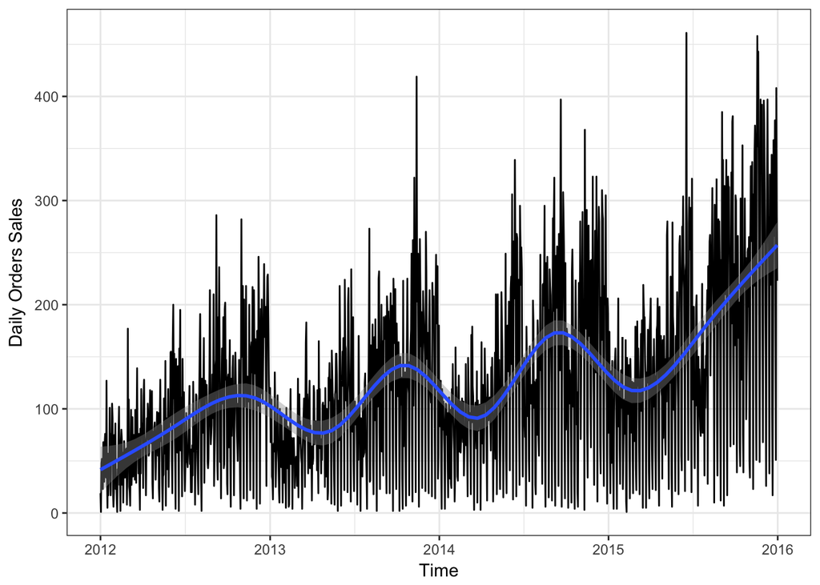

```r
# Your code here
library(lubridate)
orders$Order.Date <- as.Date(orders$Order.Date,"%m/%d/%y")
orders$Order.Month <- month(orders$Order.Date)
daily <- orders %>%
  group_by(Order.Date) %>%
  summarise( daily_quantity=sum(Quantity))

ggplot(daily, aes(Order.Date, daily_quantity)) +
  geom_line() +
  xlab("Time") +
  ylab("Daily Orders Sales") +
  theme_bw() +
  geom_smooth()
```

This plots implies there is seasonal trend, so we can investigate if the series are influenced by the month.

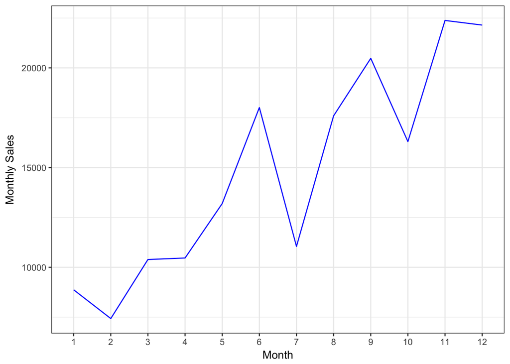

```r
monthly <- orders %>%
  group_by(Order.Month) %>%
  summarise(monthly_quantity=sum(Quantity))

ggplot(monthly, aes(as.factor(Order.Month), monthly_quantity, group=1)) +
  geom_line(color="Blue") +
  xlab("Month") +
  ylab("Monthly Sales") +
  theme_bw()
```

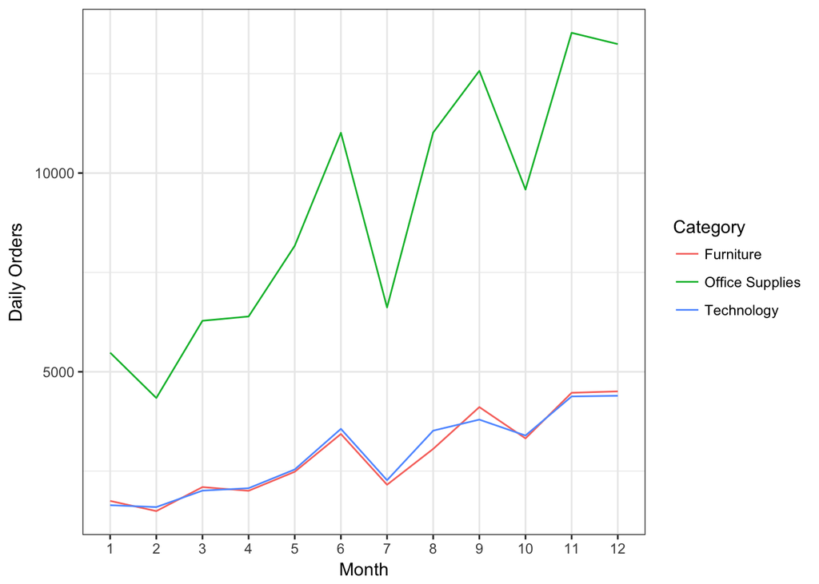

```r
month_cat <- orders %>%
  group_by(Order.Month, Category)%>%
  summarise(monthly_quantity=sum(Quantity))
ggplot(month_cat, aes(as.factor(Order.Month), monthly_quantity, group=Category, color=Category)) +
  geom_line() +
  xlab("Month") +
  ylab("Daily Orders") +
  theme_bw()
```

Looks like there is a peak during the holiday seasons and big drops in July and October.